# data_structure

# Description

In this document, are the tests concerning the creation of different data structure and their filling. We have 5 types, a list composed of objects, a class which has a list composed of objects, a data frame based on an object and composed of an objects’ list, a tibble based on a data frame and composed of an objects’ list and a data table also based on a data frame and composed of an objects’ list.

Each object is composed of a name (character), a beginning and end date (numeric), a xml document (character), a ground_name (character),a fstation (character),a fclim1 (character),a fclim2 (character), a culturean (numeric), a number of plant (numeric), a simulation code (numeric), a data’s list for the first dominant plant (character) and the same goes for the second dominant plant, an observation file (character) and the last is an element list that can be modify as we want.

The dominant plants lists are composed of a fplt (character), a ftec (character) and a flai (character)

# Tests

Before beginning the tests, let’s declare some variables that will be used in graphs.

```
##
## Number of elements :  1000
## list
```

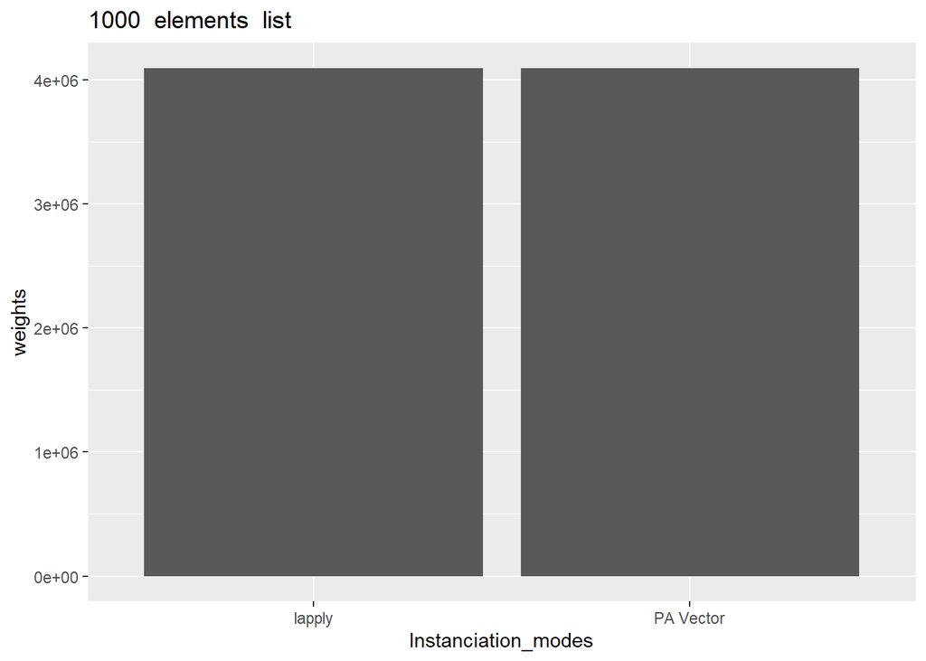

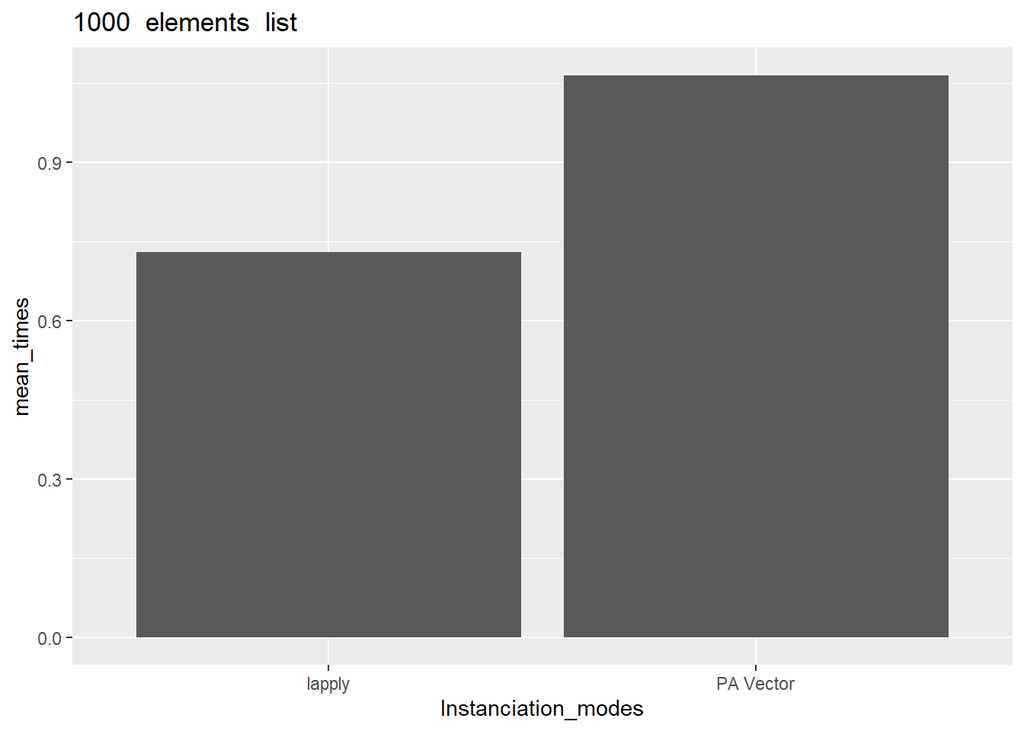

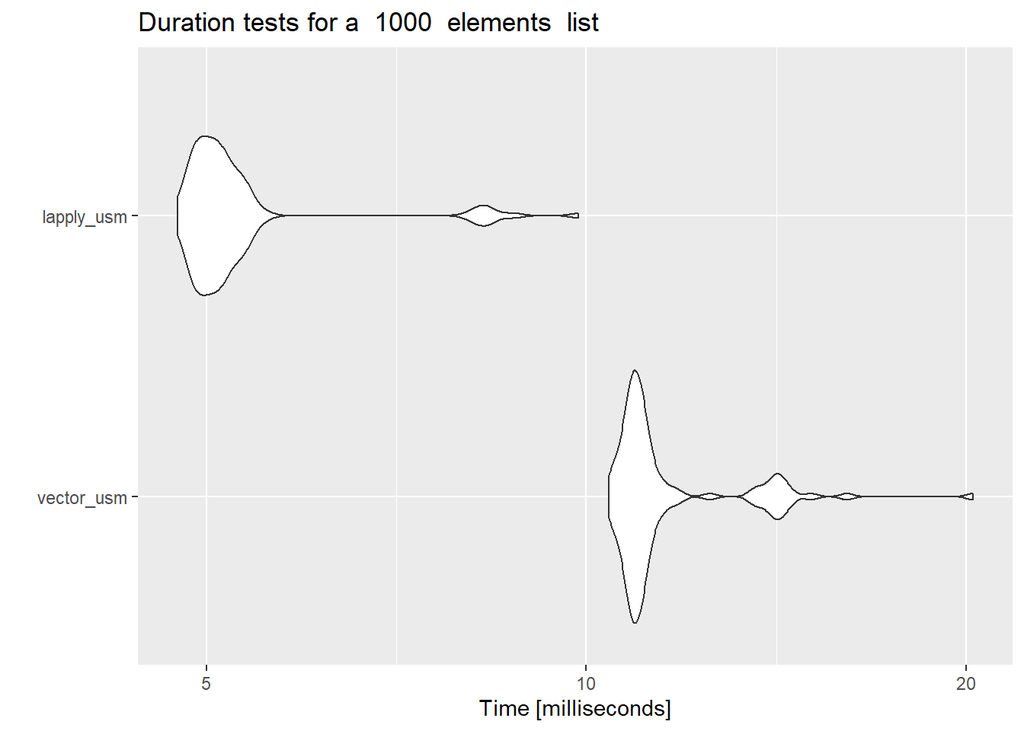

```
## class
```

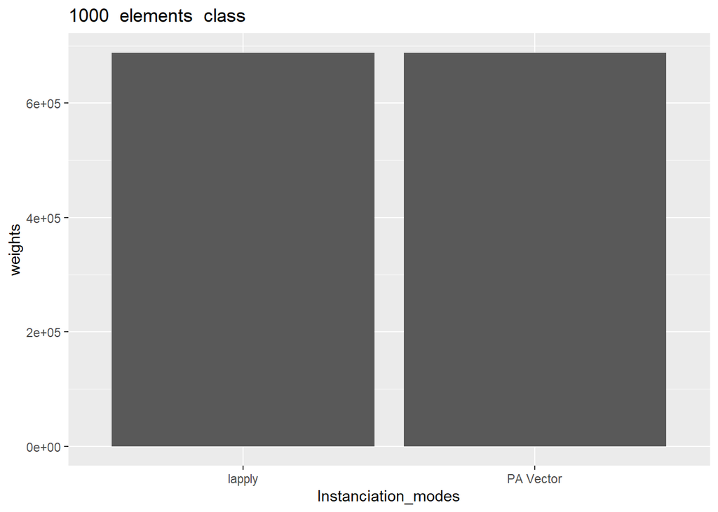

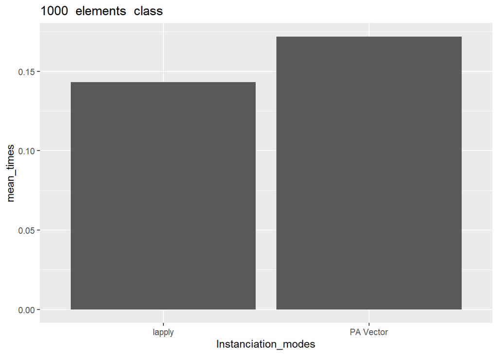

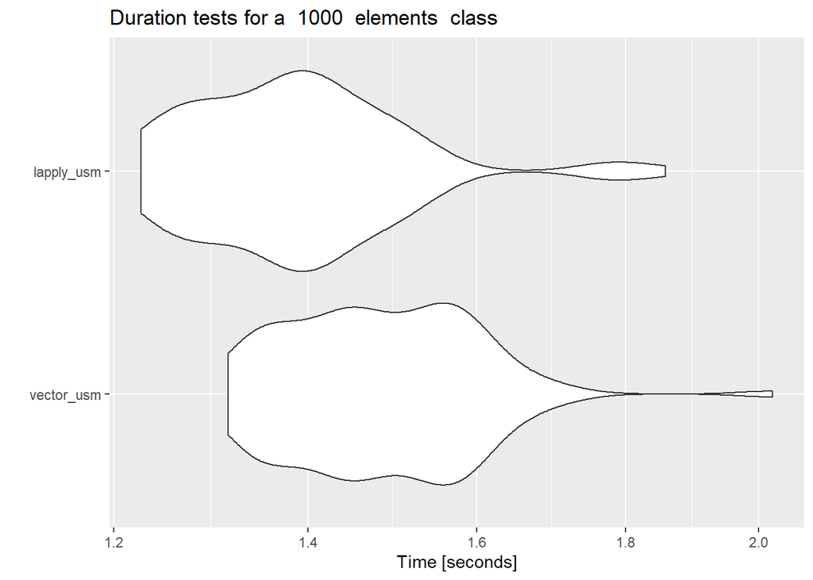

```
## dataframe
```

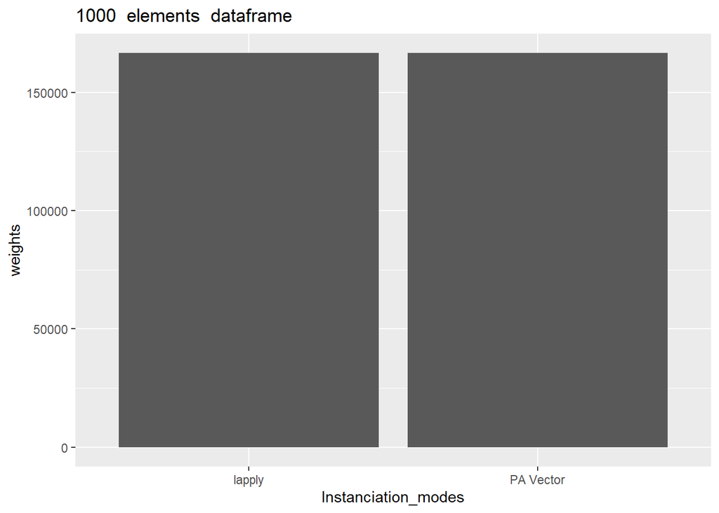

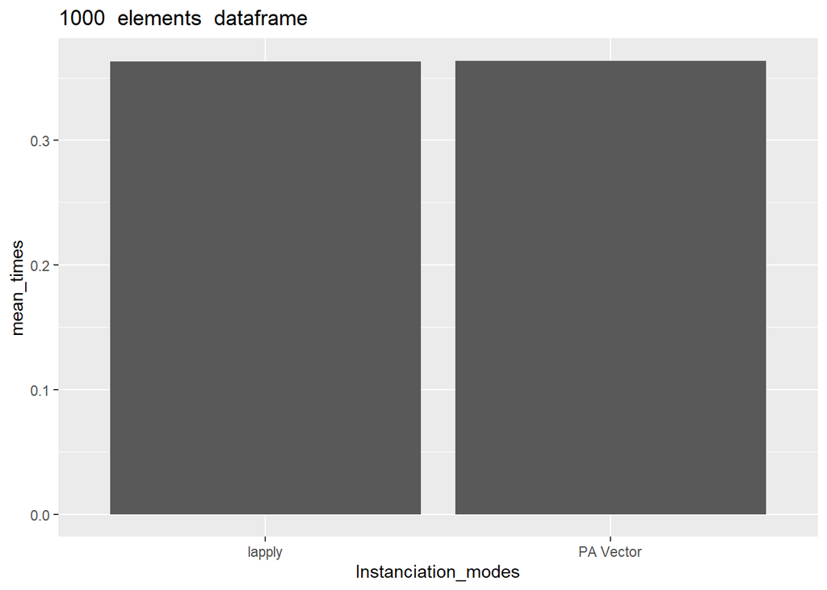

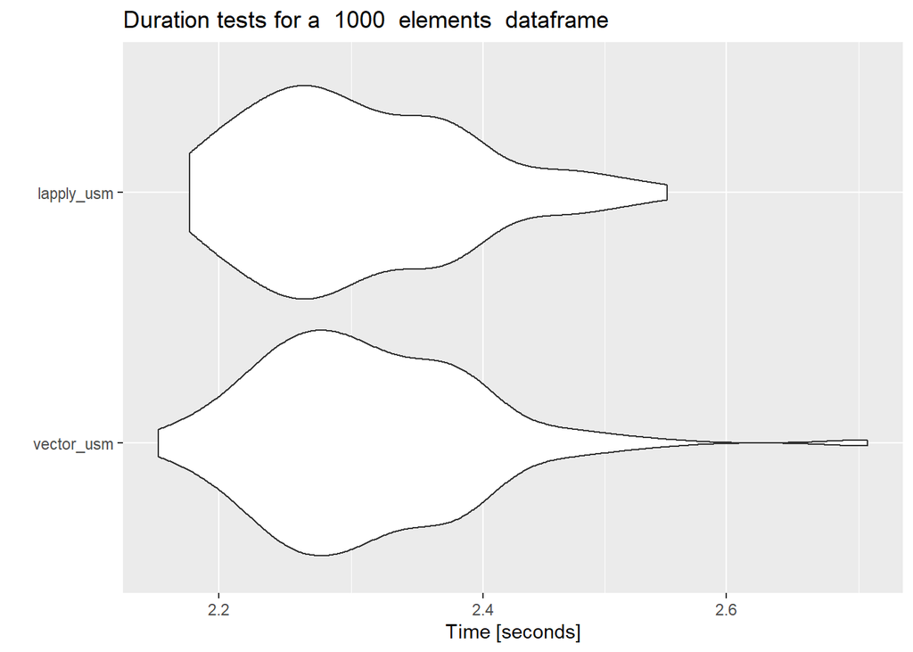

```
## datatable
```

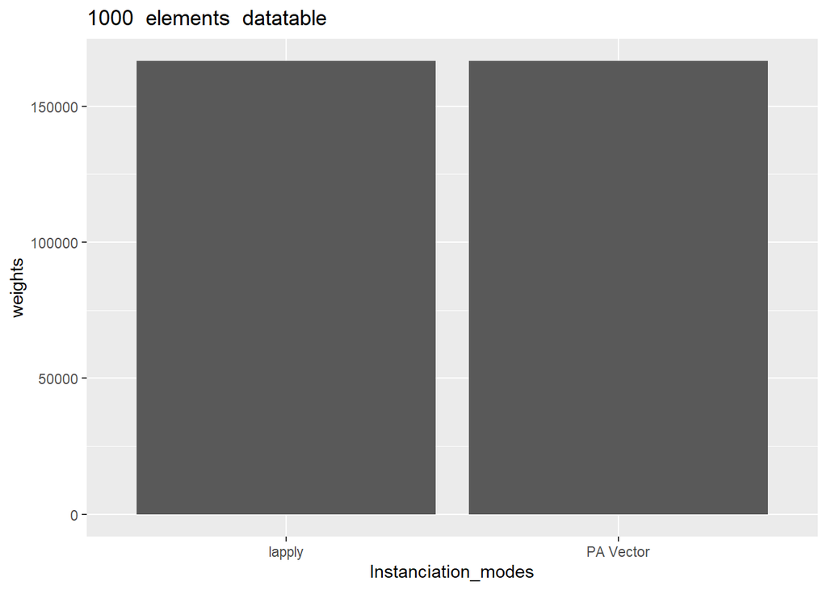

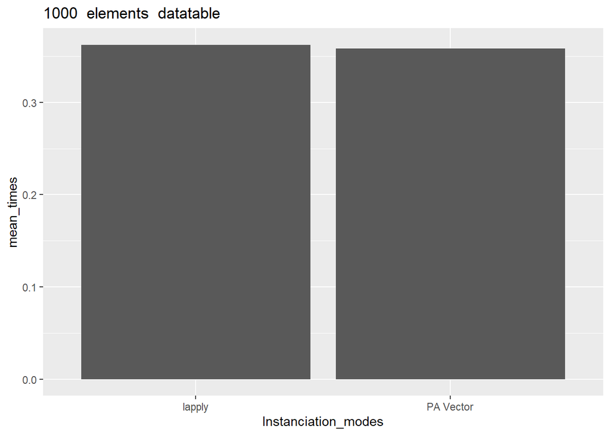

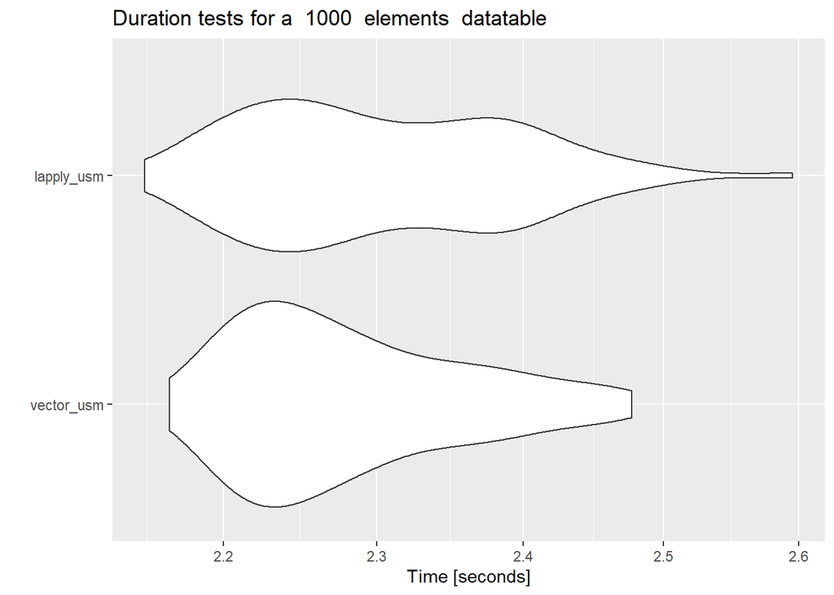

```
## tibble
```

[39 more figures not shown]

```r
## functions file
source("data_structure_functions.R")

########################### LIBRARIES & GLOBAL VARIABLES/FUNCTIONs ################################
library(microbenchmark)
library(ggplot2)
library(tibble)
library(data.table)
library(dplyr)
library(lobstr)

# used for graph
Structures_types <- c("list","class","dataframe","datatable","tibble") # list which contains the structures' types
Instanciation_methods <- c("PA Vector","lapply") # list which contains the differents instanciations methods

# used for global recap plot
all_weight <- list() # used to store the minimum weights for all the instances
all_time <- list() # used to store the minimum generation time for all the instances

# list which store the differents instances' size
num_elem <- c(1000,5000,10000)#,1000000)

# main loop
for (i in num_elem) {

  cat("\nNumber of elements : ",i,"\n")

  # loop_weight will be used to store the min weight among the instances' weights in the j-th loop
  loop_weight <- list()
  # loop_time is the same as loop_weight but it will store the min generation time
  loop_time <- list()

  # loop that will take vector_method and lapply_method together for the same structure because
  # list_vector and list_lapply have the same size
  for (j in 1:5) {

      cat(Structures_types[j],"\n")

      # instance_weight will be used to store the weight of the instances in the i-th loop

      test <- eval(parse(text=paste("vector_usm_",Structures_types[j],"(",i,")",sep="")))
      instance_weight <- object.size(test)

      test <- eval(parse(text=paste("lapply_usm_",Structures_types[j],"(",i,")",sep="")))
      instance_weight <- append(instance_weight,object.size(test))

      plot_weight <- data.frame(Instanciation_modes = Instanciation_methods,weights = instance_weight)

      graph <- ggplot(data = plot_weight,aes(x =Instanciation_modes, y=weights)) +
        geom_bar(stat = "identity")
      print(graph + ggtitle(sprintf("%d %s %s",i," elements ",Structures_types[j])))

      if (length(loop_weight) == 0) {
        loop_weight <- min(instance_weight)
      }
      else {
        loop_weight <- append(loop_weight,min(instance_weight))
      }

      if (length(all_weight) == 0) {
        all_weight <- min(instance_weight)
      }
      else {
        all_weight <- append(all_weight,min(instance_weight))
      }

      benchmark <- microbenchmark(vector_usm = eval(parse(text=paste("vector_usm_",Structures_types[j],"(",i,")",sep=""))),
                                  lapply_usm = eval(parse(text=paste("lapply_usm_",Structures_types[j],"(",i,")",sep=""))),
                                  times = 100)

      if (length(loop_time) == 0) {
        loop_time <- min(summary(benchmark)$mean)
      }
      else {
        loop_time <- append(loop_time,min(summary(benchmark)$mean))
      }

      if (length(all_time) == 0) {
        all_time = min(summary(benchmark)$mean)
      }
      else {
        all_time <- append(all_time,min(summary(benchmark)$mean))
      }

      plot_time <- data.frame(Instanciation_modes = Instanciation_methods,
                              mean_times = log10(summary(benchmark)$mean))

      graph <- ggplot(data = plot_time,aes(x = Instanciation_modes, y=mean_times)) +
        geom_bar(stat = "identity")
      print(graph + ggtitle(sprintf("%d %s %s",i," elements ",Structures_types[j])))

      print(ggplot2::autoplot(benchmark) + ggtitle(sprintf("%s %d %s %s","Duration tests for a ",
                                                     i," elements ",Structures_types[j])))
    }

    # Recap for all the instances at the same size
    plot_weight_recap <- data.frame(structures = Structures_types,weight_log10 = log10(loop_weight))

    graph_weight_recap <- ggplot(data = plot_weight_recap,aes(x = structures, y=weight_log10)) +
      geom_bar(stat = "identity")
    print(graph_weight_recap + ggtitle(sprintf("%s %d %s","Weight recap for ",i," elements structures")))

    plot_time_recap <- data.frame(structures = Structures_types,times_log10 = log10(loop_time))

    graph_time_recap <- ggplot(data = plot_time_recap,aes(x = structures, y=times_log10)) +
      geom_bar(stat = "identity")
    print(graph_time_recap + ggtitle(sprintf("%s %d %s","time recap for ",i," elements Structures")))

}
```

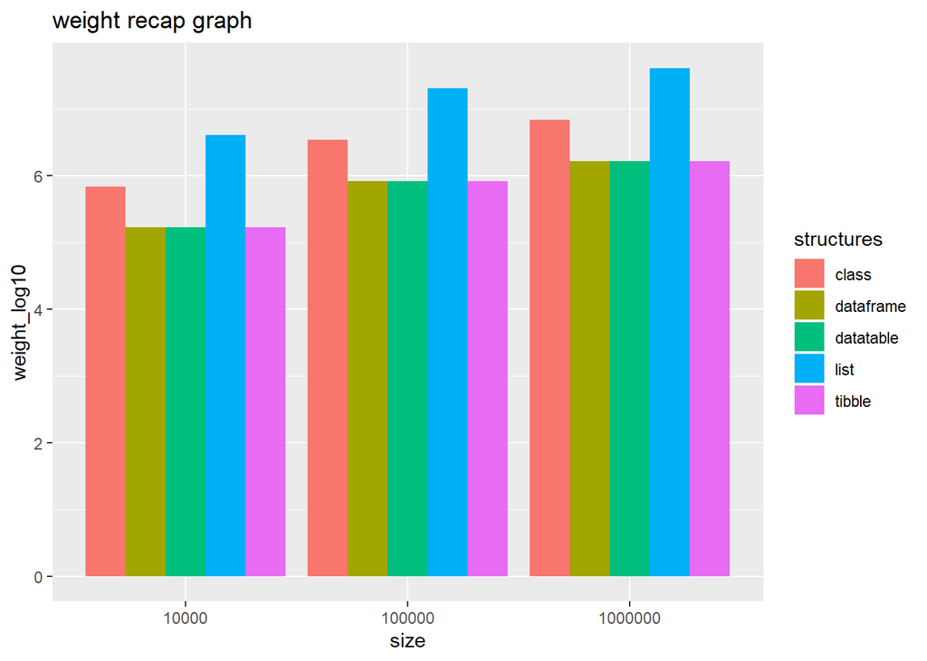

```r
# GLOBAL Recap

structures <- rep(Structures_types,3)
times_log10 <- log10(all_time)
weight_log10 <- log10(all_weight)
size <- c("10000","10000","10000","10000","10000","100000","100000","100000","100000","100000",
         "1000000","1000000","1000000","1000000","1000000")

global_plot_weight_recap <- data.frame(structures,weight_log10,size)

global_graph_weight_recap <- ggplot(data = global_plot_weight_recap,aes(x = size, y=weight_log10, fill = structures)) +
  geom_bar(position = "dodge", stat = "identity")
global_graph_weight_recap + ggtitle(sprintf("%s","weight recap graph"))
```

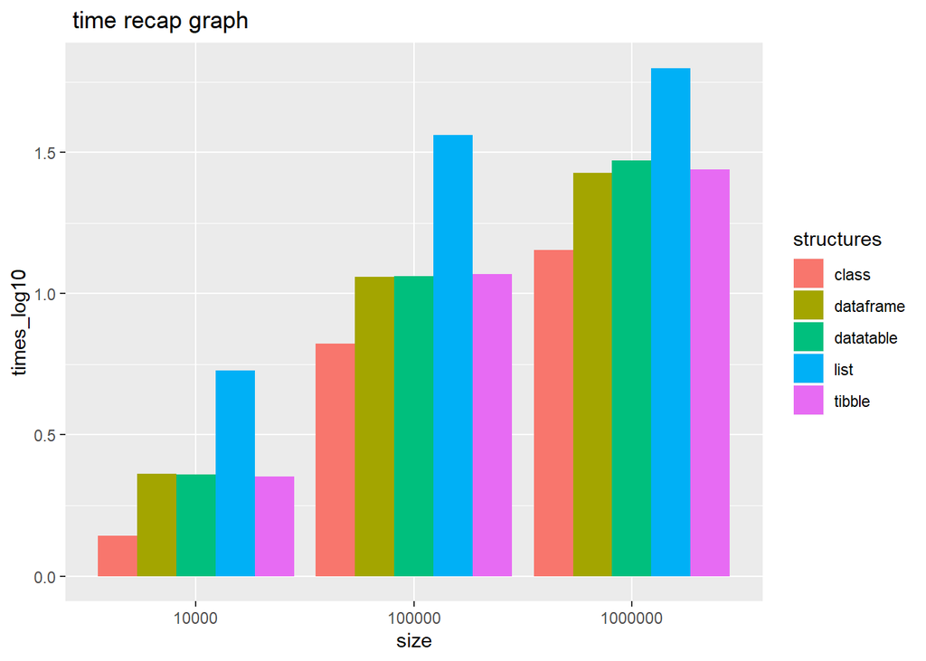

```r
global_plot_time_recap <- data.frame(structures,times_log10,size)

global_graph_time_recap <- ggplot(data = global_plot_time_recap,aes(x = size, y=times_log10,fill = structures)) +
  geom_bar(position = "dodge",stat = "identity")
global_graph_time_recap + ggtitle(sprintf("%s"," time recap graph"))
```